# **給非工程師的一日入門: 我們與Python的距離**

(目標時數: 6小時)

## 許sir

#### > ## [系統環境]

- ### Windows 10
- ### Anaconda 5.7.4
- ### Python 3.7.1

## [準備作業] 視覺化文字編碼套件

### Python資料視覺化主要有三大套件：

- 'Matplotlib': 指令功能齊全，歷史最悠久的套件，己乎沒有圖示畫不出來的，但也最複雜
- 'Seaborn': 是在Matplot的基礎上實作更高階的視覺化API，可以讓畫圖變得更方便、容易。
- 'Plotly': 好看的各種視覺化圖表，可做出互動化的介面。但Plotly並沒有在Anaconda裡面，所以要在先下pip install plotly進行安裝
- 在matplotlib 或 Seaborn 中，對於中文必須特別設定，否則圖不會顯示中文
- 請採用以下設定，請參考
  - Windows版本 https://reurl.cc/yWYQE
  - Mac 版本 https://reurl.cc/4Yj1K
- 建議:
  - Mac可用字體：SimHei
  - Windows 可用字體：Microsoft JhengHei

## [課程前言]. 是**人工**智慧、還是**工人**智慧

### Q1: 你知道，到底從資料端的角度，機器學習跟人工智慧到底有甚麼不同嗎?

[figure not shown]

### 從定義上來看

- AI: 計算機模仿人類思考進而模擬人類的能力/行為。
- ML: 從資料中學習模型。
- DL: 利用多層的非線性學習資料表徵

### Q2: 那Machine Learning 跟 Deep Learning有甚麼不同?

[figure not shown]

### Q3: Python 可以滿足我對ML或DL的需求嗎?

[figure not shown]

### 請你不要對AI 有任何不切實際的想像，絕大多數市面上所宣稱的AI，其實很可能沒有用到任何ML或DL的技術

### 前置作業是很漫長的

[figure not shown]

## [本次課程架構]

#### 資料科學生態系（Numpy、Scipy、Pandas、Scikit-learn、Statsmodels、Matplotlib、Scrapy、Keras、TensorFlow 等）

Python 可以做很多事，我們會將系列著重在Data Mining / Computing

- [PART 1]. 基本Anaconda使用方法
- [PART 2]. 開始使用 pandas
- [PART 3]. 探索性分析
- [PART 4]. 基本Data ETL
- [PART 5]. 基本Data ETL Ⅱ
- [PART 6]. 遺漏值處理
- [PART 7]. 機器學習概論

## [PART 1]. 基本Anaconda使用方法

[figure not shown]

## [1-1] 一些快捷鍵的方法

[figure not shown]

## [1-2]. 常用的Markdown指令

### [A].字型大小

# Hello World

## Hello World

### Hello World

#### Hello World

## [B].*斜體* and **粗體**

## [C]. 條列語句

### 你覺得寫程式**__**:

- 1.令人開心
- 2.覺得沮喪
- 3.超不爽
- 4.一塊蛋糕

## [D]. 上下標

### 單位: KM<sup>2</sup>

### 二氧化碳: CO<sub>2</sub>

## [D].表格

| 第一組 | 第二組 | 第三組 | 第四組 | 第五組 |
| --- | --- | --- | --- | --- |
| 樣本1 | 樣本2 | 樣本3 | 樣本4 | 樣本5 |
| 樣本6 | 樣本7 | 樣本8 | 樣本9 | 樣本10 |

## [E]. 分隔線

## [PART 2]. 貓熊? Pandas?

- Pandas簡單來說就是把Excel的表格觀念丟到Python，在Excel所有的操作都可以透過Pandas的函式做簡單的處理，想是欄位的加總、分群、樞紐分析表、小計、畫折線圖、圓餅圖等等…
- Pandas背後的數值型態都是Numpy，Numpy的資料結構可以幫助Pandas在執行運算上更有效率以及更省記憶體。
- matplotlib.pyplot 是視覺化套件

[figure not shown]

## [2-1]. 基本資料結構簡介

Numpy 是 Python 的一個重要模組，主要用於資料處理上。Numpy 底層以 C 和 Fortran 語言實作，所以能快速操作多重維度的陣列。當 Python 處理龐大資料時，其原生 list 效能表現並不理想（但可以動態存異質資料），而 Numpy 具備平行處理的能力，可以將操作動作一次套用在大型陣列上。此外 Python 其餘重量級的資料科學相關套件（例如：Pandas、SciPy、Scikit-learn 等）都幾乎是奠基在 Numpy 的基礎上。

[figure not shown]

## [2-2]. Pandas 的資料結構

Pandas 有兩個基本資料結構:

- **DataFrame**: 可以想成一個表格。
- **Series**: 表格的某一列、某一行, 基本上就是我們以前的 list 或 array

一個 DataFrame, 我們有 `index` (列的名稱), `columns` (行的名稱)。

#### DataFrame

[figure not shown]

## [2-3 標準開始動作]. 如果你用python的目標是科學計算或數值分析，基本是引⼊三個套件

```python
%matplotlib inline
##將後續畫圖的結果直接顯現在網頁中

import numpy as np
import matplotlib.pyplot as plt
import pandas as pd  #
```

## 輸入資料與資料格式

- df 是標準的叫法 (雖然這名稱我們隨便取也可以), 意思是 Data Frame, 這是 pandas 兩大資料結構之一。我們可以把 Data Frame 想成一張表格 (雖然其實可以是很多張表格)。
- 我們來看看我們 df 的前五筆資料。

```python
df = pd.read_csv("data/grades.csv") #這裡的df是 data-frame的意思，你也可以用其他名稱代替
```

#### Python 3.x 中，python 直譯器預期的 .py 編碼，預設是 UTF-8

因此如果你的跑出來是亂碼，可以用 df8 = pd.read_csv("data/grades.csv",encoding='utf-8')

## [2-4]. Pandas的小技巧

```python
print(df.shape)# 印出資料維度
```

```
(100, 6)
```

```python
df.head() #看前五筆資料
```

|  | 姓名 | 國文 | 英文 | 數學 | 自然 | 社會 |
| --- | --- | --- | --- | --- | --- | --- |
| 0 | 劉俊安 | 9 | 10 | 15 | 10 | 13 |
| 1 | 胡玉華 | 10 | 10 | 10 | 8 | 9 |
| 2 | 黃淑婷 | 13 | 15 | 8 | 11 | 14 |
| 3 | 陳上紫 | 10 | 10 | 8 | 9 | 14 |
| 4 | 崔靜成 | 13 | 12 | 14 | 12 | 13 |

```python
df.tail() #看後面幾筆
```

|  | 姓名 | 國文 | 英文 | 數學 | 自然 | 社會 |
| --- | --- | --- | --- | --- | --- | --- |
| 95 | 蔡佳燕 | 9 | 10 | 9 | 13 | 14 |
| 96 | 吳筱婷 | 8 | 10 | 14 | 10 | 15 |
| 97 | 陳家銘 | 14 | 9 | 11 | 8 | 12 |
| 98 | 李明威 | 15 | 9 | 8 | 9 | 15 |
| 99 | 農揚勇 | 9 | 11 | 12 | 12 | 10 |

### [補充].怎麼查語法

- 假設我不知道上面這行 df.tail() 在幹嘛的

```python
#??tail()
```

```python
print(df.info())# 印出 DataFrame 資料概況, 順便check有沒有missing value
```

```
<class 'pandas.core.frame.DataFrame'>
RangeIndex: 100 entries, 0 to 99
Data columns (total 6 columns):
姓名    100 non-null object
國文    100 non-null int64
英文    100 non-null int64
數學    100 non-null int64
自然    100 non-null int64
社會    100 non-null int64
dtypes: int64(5), object(1)
memory usage: 4.8+ KB
None
```

```python
df.select_dtypes(include=['float64', 'int64'])
```

|  | 國文 | 英文 | 數學 | 自然 | 社會 |
| --- | --- | --- | --- | --- | --- |
| 0 | 9 | 10 | 15 | 10 | 13 |
| 1 | 10 | 10 | 10 | 8 | 9 |
| 2 | 13 | 15 | 8 | 11 | 14 |
| 3 | 10 | 10 | 8 | 9 | 14 |
| 4 | 13 | 12 | 14 | 12 | 13 |
| 5 | 13 | 12 | 12 | 12 | 8 |
| 6 | 11 | 13 | 10 | 10 | 14 |
| 7 | 8 | 9 | 10 | 10 | 8 |
| 8 | 9 | 9 | 12 | 10 | 10 |
| 9 | 10 | 15 | 12 | 11 | 9 |
| 10 | 14 | 9 | 8 | 10 | 12 |
| 11 | 13 | 9 | 13 | 14 | 15 |
| 12 | 11 | 15 | 11 | 14 | 15 |
| 13 | 15 | 14 | 9 | 12 | 10 |
| 14 | 8 | 13 | 10 | 13 | 14 |
| 15 | 11 | 8 | 10 | 12 | 15 |
| 16 | 14 | 9 | 11 | 10 | 9 |
| 17 | 12 | 11 | 13 | 12 | 9 |
| 18 | 9 | 8 | 8 | 8 | 12 |
| 19 | 14 | 9 | 11 | 15 | 9 |
| 20 | 13 | 9 | 13 | 14 | 13 |
| 21 | 9 | 8 | 11 | 13 | 8 |
| 22 | 12 | 14 | 10 | 9 | 9 |
| 23 | 10 | 13 | 12 | 14 | 10 |
| 24 | 10 | 12 | 15 | 10 | 14 |
| 25 | 13 | 13 | 14 | 13 | 12 |
| 26 | 13 | 11 | 9 | 14 | 9 |
| 27 | 8 | 13 | 14 | 8 | 10 |
| 28 | 15 | 14 | 8 | 12 | 8 |
| 29 | 14 | 11 | 13 | 8 | 11 |
| ... | ... | ... | ... | ... | ... |
| 70 | 9 | 13 | 15 | 8 | 14 |
| 71 | 9 | 8 | 13 | 9 | 12 |
| 72 | 10 | 9 | 13 | 8 | 10 |
| 73 | 13 | 15 | 15 | 8 | 8 |
| 74 | 14 | 9 | 10 | 14 | 11 |
| 75 | 13 | 8 | 9 | 10 | 11 |
| 76 | 9 | 12 | 15 | 13 | 12 |
| 77 | 13 | 10 | 11 | 8 | 13 |
| 78 | 12 | 13 | 13 | 9 | 11 |
| 79 | 9 | 10 | 12 | 15 | 13 |
| 80 | 13 | 15 | 12 | 13 | 13 |
| 81 | 11 | 8 | 13 | 9 | 15 |
| 82 | 11 | 14 | 9 | 15 | 9 |
| 83 | 10 | 14 | 15 | 13 | 13 |
| 84 | 10 | 8 | 9 | 9 | 15 |
| 85 | 10 | 11 | 15 | 12 | 8 |
| 86 | 11 | 10 | 14 | 8 | 13 |
| 87 | 10 | 13 | 14 | 13 | 15 |
| 88 | 11 | 8 | 14 | 12 | 10 |
| 89 | 13 | 13 | 10 | 14 | 9 |
| 90 | 8 | 11 | 15 | 10 | 15 |
| 91 | 14 | 11 | 11 | 13 | 12 |
| 92 | 8 | 12 | 14 | 12 | 11 |
| 93 | 11 | 9 | 11 | 8 | 8 |
| 94 | 10 | 9 | 10 | 11 | 15 |
| 95 | 9 | 10 | 9 | 13 | 14 |
| 96 | 8 | 10 | 14 | 10 | 15 |
| 97 | 14 | 9 | 11 | 8 | 12 |
| 98 | 15 | 9 | 8 | 9 | 15 |
| 99 | 9 | 11 | 12 | 12 | 10 |

100 rows × 5 columns

```python
df2 = df.copy() #整份資料及要copy成另一份時
df2.head() #看前五筆資料
```

|  | 姓名 | 國文 | 英文 | 數學 | 自然 | 社會 |
| --- | --- | --- | --- | --- | --- | --- |
| 0 | 劉俊安 | 9 | 10 | 15 | 10 | 13 |
| 1 | 胡玉華 | 10 | 10 | 10 | 8 | 9 |
| 2 | 黃淑婷 | 13 | 15 | 8 | 11 | 14 |
| 3 | 陳上紫 | 10 | 10 | 8 | 9 | 14 |
| 4 | 崔靜成 | 13 | 12 | 14 | 12 | 13 |

```python
df3=df2.transpose() #有時候我們會無聊的需要轉置
df3.head() #看前五筆資料
```

|  | 0 | 1 | 2 | 3 | 4 | 5 | 6 | 7 | 8 | 9 | ... | 90 | 91 | 92 | 93 | 94 | 95 | 96 | 97 | 98 | 99 |
| --- | --- | --- | --- | --- | --- | --- | --- | --- | --- | --- | --- | --- | --- | --- | --- | --- | --- | --- | --- | --- | --- |
| 姓名 | 劉俊安 | 胡玉華 | 黃淑婷 | 陳上紫 | 崔靜成 | 張雅岳 | 梁俊翔 | 林金鳳 | 許協旺 | 郭雅惠 | ... | 胡勝傑 | 陳登翰 | 蔡淑孝 | 李曼夢 | 林與忠 | 蔡佳燕 | 吳筱婷 | 陳家銘 | 李明威 | 農揚勇 |
| 國文 | 9 | 10 | 13 | 10 | 13 | 13 | 11 | 8 | 9 | 10 | ... | 8 | 14 | 8 | 11 | 10 | 9 | 8 | 14 | 15 | 9 |
| 英文 | 10 | 10 | 15 | 10 | 12 | 12 | 13 | 9 | 9 | 15 | ... | 11 | 11 | 12 | 9 | 9 | 10 | 10 | 9 | 9 | 11 |
| 數學 | 15 | 10 | 8 | 8 | 14 | 12 | 10 | 10 | 12 | 12 | ... | 15 | 11 | 14 | 11 | 10 | 9 | 14 | 11 | 8 | 12 |
| 自然 | 10 | 8 | 11 | 9 | 12 | 12 | 10 | 10 | 10 | 11 | ... | 10 | 13 | 12 | 8 | 11 | 13 | 10 | 8 | 9 | 12 |

5 rows × 100 columns

```python
df2['英文'].value_counts() #次數分配
```

```
9     16
14    13
13    13
12    13
10    12
8     12
11    11
15    10
Name: 英文, dtype: int64
```

```python
df2['英文'].value_counts().reset_index() #也可以做成表格比較好看，但要小心前後index的關係
```

|  | index | 英文 |
| --- | --- | --- |
| 0 | 9 | 16 |
| 1 | 14 | 13 |
| 2 | 13 | 13 |
| 3 | 12 | 13 |
| 4 | 10 | 12 |
| 5 | 8 | 12 |
| 6 | 11 | 11 |
| 7 | 15 | 10 |

```python
df['英文'].value_counts().reset_index().sort_values(by='index')
```

|  | index | 英文 |
| --- | --- | --- |
| 5 | 8 | 12 |
| 0 | 9 | 16 |
| 4 | 10 | 12 |
| 6 | 11 | 11 |
| 3 | 12 | 13 |
| 2 | 13 | 13 |
| 1 | 14 | 13 |
| 7 | 15 | 10 |

```python
df["數學"] #列出某一行
```

```
0     15
1     10
2      8
3      8
4     14
5     12
6     10
7     10
8     12
9     12
10     8
11    13
12    11
13     9
14    10
```

[output cut: 47 more lines]

## [PART 3]. 探索性分析

## [3-1].基本敘述性統計

```python
df.數學.mean()
```

```
11.57
```

```python
df.國文.mean()
```

```
11.39
```

```python
df.數學.std()
```

```
2.310516143307562
```

```python
df.describe() #基本統計量
```

|  | 國文 | 英文 | 數學 | 自然 | 社會 |
| --- | --- | --- | --- | --- | --- |
| count | 100.000000 | 100.000000 | 100.000000 | 100.00000 | 100.00000 |
| mean | 11.390000 | 11.380000 | 11.570000 | 11.03000 | 11.83000 |
| std | 2.196853 | 2.273164 | 2.310516 | 2.21772 | 2.48655 |
| min | 8.000000 | 8.000000 | 8.000000 | 8.00000 | 8.00000 |
| 25% | 9.000000 | 9.000000 | 10.000000 | 9.00000 | 9.00000 |
| 50% | 11.000000 | 11.000000 | 11.000000 | 11.00000 | 12.00000 |
| 75% | 13.000000 | 13.000000 | 14.000000 | 13.00000 | 14.00000 |
| max | 15.000000 | 15.000000 | 15.000000 | 15.00000 | 15.00000 |

```python
df.corr() #相關係數
```

|  | 國文 | 英文 | 數學 | 自然 | 社會 |
| --- | --- | --- | --- | --- | --- |
| 國文 | 1.000000 | 0.160158 | -0.310899 | -0.110236 | -0.028421 |
| 英文 | 0.160158 | 1.000000 | 0.025656 | 0.113929 | -0.063512 |
| 數學 | -0.310899 | 0.025656 | 1.000000 | 0.014371 | 0.041651 |
| 自然 | -0.110236 | 0.113929 | 0.014371 | 1.000000 | -0.156594 |
| 社會 | -0.028421 | -0.063512 | 0.041651 | -0.156594 | 1.000000 |

```python
df[["國文", "英文", "數學"]].sum(1)#選三科相加
```

```
0     34
1     30
2     36
3     28
4     39
5     37
6     34
7     27
8     30
9     37
10    31
11    35
12    37
13    38
14    31
```

[output cut: 47 more lines]

```python
df[df.數學==15] #找出數學滿級分的同學
```

|  | 姓名 | 國文 | 英文 | 數學 | 自然 | 社會 |
| --- | --- | --- | --- | --- | --- | --- |
| 0 | 劉俊安 | 9 | 10 | 15 | 10 | 13 |
| 24 | 陳竹伯 | 10 | 12 | 15 | 10 | 14 |
| 36 | 詹威德 | 12 | 13 | 15 | 10 | 14 |
| 37 | 曾怡君 | 11 | 12 | 15 | 13 | 14 |
| 39 | 段冠廷 | 9 | 8 | 15 | 12 | 15 |
| 59 | 芮秋辛 | 11 | 10 | 15 | 10 | 8 |
| 67 | 林哲法 | 14 | 9 | 15 | 10 | 14 |
| 70 | 葉儀依 | 9 | 13 | 15 | 8 | 14 |
| 73 | 吳志遠 | 13 | 15 | 15 | 8 | 8 |
| 76 | 周育霖 | 9 | 12 | 15 | 13 | 12 |
| 83 | 李士賢 | 10 | 14 | 15 | 13 | 13 |
| 85 | 張雅彬 | 10 | 11 | 15 | 12 | 8 |
| 90 | 胡勝傑 | 8 | 11 | 15 | 10 | 15 |

```python
df[(df.數學==15) & (df.英文==15)] #找出數學和英文都滿級分的同學。要注意 and 要用 &, or 要用 |。每個條件一定要加弧號
```

|  | 姓名 | 國文 | 英文 | 數學 | 自然 | 社會 |
| --- | --- | --- | --- | --- | --- | --- |
| 73 | 吳志遠 | 13 | 15 | 15 | 8 | 8 |

```python
df[(df.數學==15) | (df.英文==15)] #找出數學 或 英文 滿級分的同學。要注意 and 要用 &, or 要用 |。每個條件一定要加弧號
```

|  | 姓名 | 國文 | 英文 | 數學 | 自然 | 社會 |
| --- | --- | --- | --- | --- | --- | --- |
| 0 | 劉俊安 | 9 | 10 | 15 | 10 | 13 |
| 2 | 黃淑婷 | 13 | 15 | 8 | 11 | 14 |
| 9 | 郭雅惠 | 10 | 15 | 12 | 11 | 9 |
| 12 | 李正偉 | 11 | 15 | 11 | 14 | 15 |
| 24 | 陳竹伯 | 10 | 12 | 15 | 10 | 14 |
| 33 | 王佳蓉 | 14 | 15 | 9 | 9 | 8 |
| 36 | 詹威德 | 12 | 13 | 15 | 10 | 14 |
| 37 | 曾怡君 | 11 | 12 | 15 | 13 | 14 |
| 39 | 段冠廷 | 9 | 8 | 15 | 12 | 15 |
| 43 | 林士茜 | 12 | 15 | 9 | 9 | 13 |
| 54 | 陳怡潔 | 15 | 15 | 9 | 15 | 11 |
| 55 | 林意珍 | 9 | 15 | 11 | 13 | 9 |
| 57 | 胡淳茜 | 12 | 15 | 14 | 13 | 11 |
| 59 | 芮秋辛 | 11 | 10 | 15 | 10 | 8 |
| 67 | 林哲法 | 14 | 9 | 15 | 10 | 14 |
| 70 | 葉儀依 | 9 | 13 | 15 | 8 | 14 |
| 73 | 吳志遠 | 13 | 15 | 15 | 8 | 8 |
| 76 | 周育霖 | 9 | 12 | 15 | 13 | 12 |
| 80 | 施雅鈴 | 13 | 15 | 12 | 13 | 13 |
| 83 | 李士賢 | 10 | 14 | 15 | 13 | 13 |
| 85 | 張雅彬 | 10 | 11 | 15 | 12 | 8 |
| 90 | 胡勝傑 | 8 | 11 | 15 | 10 | 15 |

```python
df["國英數"] = df[["國文", "英文", "數學"]].sum(1) #新增一個欄位
df.head()
```

|  | 姓名 | 國文 | 英文 | 數學 | 自然 | 社會 | 國英數 |
| --- | --- | --- | --- | --- | --- | --- | --- |
| 0 | 劉俊安 | 9 | 10 | 15 | 10 | 13 | 34 |
| 1 | 胡玉華 | 10 | 10 | 10 | 8 | 9 | 30 |
| 2 | 黃淑婷 | 13 | 15 | 8 | 11 | 14 | 36 |
| 3 | 陳上紫 | 10 | 10 | 8 | 9 | 14 | 28 |
| 4 | 崔靜成 | 13 | 12 | 14 | 12 | 13 | 39 |

```python
df["加權"] = df.數學*2 + df.英文
df.head()
```

|  | 姓名 | 國文 | 英文 | 數學 | 自然 | 社會 | 國英數 | 加權 |
| --- | --- | --- | --- | --- | --- | --- | --- | --- |
| 0 | 劉俊安 | 9 | 10 | 15 | 10 | 13 | 34 | 40 |
| 1 | 胡玉華 | 10 | 10 | 10 | 8 | 9 | 30 | 30 |
| 2 | 黃淑婷 | 13 | 15 | 8 | 11 | 14 | 36 | 31 |
| 3 | 陳上紫 | 10 | 10 | 8 | 9 | 14 | 28 | 26 |
| 4 | 崔靜成 | 13 | 12 | 14 | 12 | 13 | 39 | 40 |

```python
df["總級分"] = df[["國文", "英文", "數學", "社會", "自然"]].sum(1)
df.head()
```

|  | 姓名 | 國文 | 英文 | 數學 | 自然 | 社會 | 國英數 | 加權 | 總級分 |
| --- | --- | --- | --- | --- | --- | --- | --- | --- | --- |
| 0 | 劉俊安 | 9 | 10 | 15 | 10 | 13 | 34 | 40 | 57 |
| 1 | 胡玉華 | 10 | 10 | 10 | 8 | 9 | 30 | 30 | 47 |
| 2 | 黃淑婷 | 13 | 15 | 8 | 11 | 14 | 36 | 31 | 61 |
| 3 | 陳上紫 | 10 | 10 | 8 | 9 | 14 | 28 | 26 | 51 |
| 4 | 崔靜成 | 13 | 12 | 14 | 12 | 13 | 39 | 40 | 64 |

## 我們假設隨便給這組資料'性別'、'地區'及'社團'，以利後續畫圖之用

```python
df['性別'] = ['男', '女', '男', '男', '女','男', '男', '女', '女', '女',
            '男', '男', '女', '女', '女','男', '男', '女', '女', '女',
            '男', '男', '女', '男', '女', '女', '女','女', '女','男',
            '男', '男', '男', '女', '女', '女','男', '女', '女', '女',
            '男', '男', '女', '女', '女','男', '男', '男', '男', '男',
            '男', '男','男', '男', '女', '女', '女', '女', '女', '女',
            '男', '女', '女', '女','男', '男','男', '女', '女', '女',
            '男', '男', '女', '女', '女','男', '男', '男','男', '男',
            '女', '女', '女','男', '男', '男', '男', '女', '女', '女',
            '女', '女', '女', '女', '女','男', '男', '女', '女', '女']
df['地區'] = ['北', '中', '南', '東','北', '中', '南', '東', '北', '中', '南', '東','北', '中', '南', '東',
            '北', '中', '南', '東','北', '中', '南', '東','北', '中', '南', '東','北', '中', '南', '東',
            '北', '中', '南', '東','北', '中', '南', '東','北', '中', '南', '東','北', '中', '南', '東',
            '北', '中', '南', '東','北', '中', '南', '東','北', '中', '南', '東','北', '中', '南', '東',
            '北', '中', '南', '東','北', '中', '南', '東','北', '中', '南', '東','北', '中', '南', '東',
            '北', '中', '南', '東','北', '中', '南', '東','北', '中', '南', '東','北', '中', '南', '東',
            '北', '中', '南', '東' ]
df['社團'] = ['籃球','羽球','無','棒球', '直排輪','無', '橋牌', '網球', '籃球', '游泳',
           '橋牌', '網球', '籃球', '游泳','籃球','羽球','無','棒球', '直排輪','無',
           '無', '橋牌', '網球', '籃球', '游泳','籃球','羽球','無','棒球', '直排輪',
           '籃球','羽球','無','棒球', '直排輪','無', '橋牌', '網球', '籃球', '游泳',
           '無', '橋牌', '網球', '籃球', '游泳','籃球','羽球','無','棒球', '直排輪',
           '橋牌', '網球', '籃球', '游泳','籃球','羽球','無','棒球', '直排輪','無',
           '無', '橋牌', '網球', '籃球', '游泳','籃球','羽球','無','棒球', '直排輪',
           '橋牌', '網球', '籃球', '游泳','籃球','羽球','無','棒球', '直排輪','無',
           '無', '橋牌', '網球', '籃球', '游泳','籃球','羽球','無','棒球', '直排輪',
           '籃球','羽球','無','棒球', '直排輪','無', '橋牌', '網球', '籃球', '游泳',]
```

```python
 df.head()
```

|  | 姓名 | 國文 | 英文 | 數學 | 自然 | 社會 | 國英數 | 加權 | 總級分 | 性別 | 地區 | 社團 |
| --- | --- | --- | --- | --- | --- | --- | --- | --- | --- | --- | --- | --- |
| 0 | 劉俊安 | 9 | 10 | 15 | 10 | 13 | 34 | 40 | 57 | 男 | 北 | 籃球 |
| 1 | 胡玉華 | 10 | 10 | 10 | 8 | 9 | 30 | 30 | 47 | 女 | 中 | 羽球 |
| 2 | 黃淑婷 | 13 | 15 | 8 | 11 | 14 | 36 | 31 | 61 | 男 | 南 | 無 |
| 3 | 陳上紫 | 10 | 10 | 8 | 9 | 14 | 28 | 26 | 51 | 男 | 東 | 棒球 |
| 4 | 崔靜成 | 13 | 12 | 14 | 12 | 13 | 39 | 40 | 64 | 女 | 北 | 直排輪 |

```python
df.tail()
```

|  | 姓名 | 國文 | 英文 | 數學 | 自然 | 社會 | 國英數 | 加權 | 總級分 | 性別 | 地區 | 社團 |
| --- | --- | --- | --- | --- | --- | --- | --- | --- | --- | --- | --- | --- |
| 95 | 蔡佳燕 | 9 | 10 | 9 | 13 | 14 | 28 | 28 | 55 | 男 | 東 | 無 |
| 96 | 吳筱婷 | 8 | 10 | 14 | 10 | 15 | 32 | 38 | 57 | 男 | 北 | 橋牌 |
| 97 | 陳家銘 | 14 | 9 | 11 | 8 | 12 | 34 | 31 | 54 | 女 | 中 | 網球 |
| 98 | 李明威 | 15 | 9 | 8 | 9 | 15 | 32 | 25 | 56 | 女 | 南 | 籃球 |
| 99 | 農揚勇 | 9 | 11 | 12 | 12 | 10 | 32 | 35 | 54 | 女 | 東 | 游泳 |

```python
print(df.shape)# 印出資料維度
```

```
(100, 12)
```

## [3-2].資料視覺化

#### 如果你一開始的準備作業設定完成，你可以接著往下做，不然會看不到中文

```python
#基礎設定
from matplotlib.font_manager import FontProperties
import seaborn as sns
myfont=FontProperties(fname=r'C:\Users\user\Anaconda3\lib\site-packages\matplotlib\mpl-data\fonts\ttf\msj.ttf',size=14)
sns.set(font=myfont.get_family())
sns.set_style("whitegrid",{"font.sans-serif":['Microsoft JhengHei']})
```

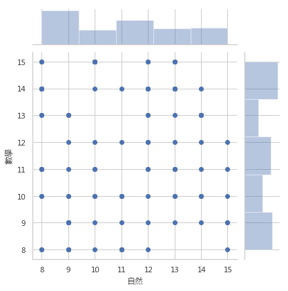

```python
sns.jointplot(x = "自然", y = "數學", data = df)#散佈圖，XY都要視數量資料
```

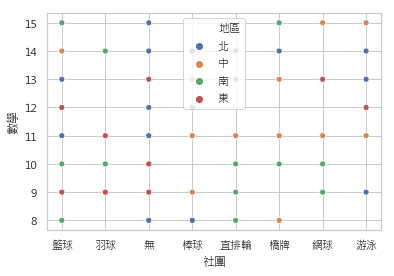

```python
sns.scatterplot(x="社團", y="數學",
                hue="地區",
                data=df)
```

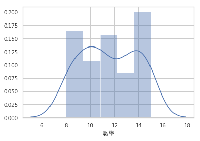

```python
#distplot的變數只能放數量資料
sns.distplot(df['數學']) #次數分佈
```

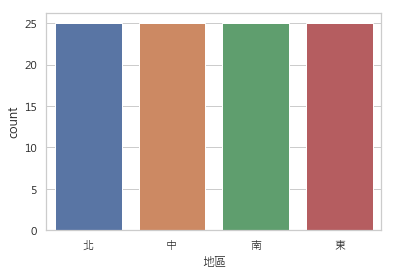

```python
sns.countplot(x = "地區", data=df)# 次數分配，countplot放屬質資料
```

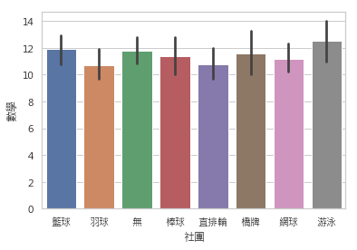

```python
sns.barplot(x="社團", y="數學", data=df)#Bar-Plot
```

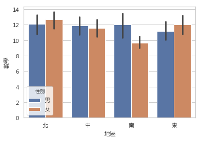

```python
sns.barplot(x="地區", y="數學", hue="性別", data=df)
```

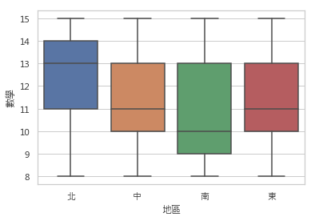

```python
sns.boxplot(x = '地區', y= '數學', data = df) #Box-Plot(第二四分位數為中位數)
```

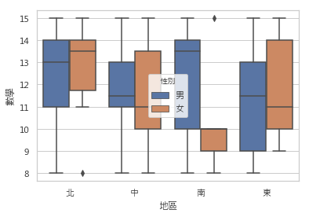

```python
sns.boxplot(x = '地區', y= '數學', data = df, hue = '性別') # hue = 'sex'以性別當圖標(第二四分位數為中位數)
```

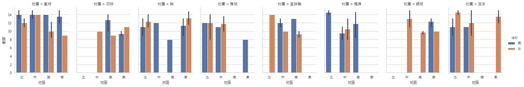

```python
#這是進階語法，可一次看多個
sns.catplot(x="地區", y="數學",
            hue="性別", col="社團",
            data=df, kind="bar",
            height=4, aspect=.7) #Cat-plot
```

## [PART 4]. 基本Data ETL

## [4-1]. 次數分配表(交叉分析)

- 單純看屬質變數的交叉分析

```python
df['性別'].value_counts() #計算一下男女的分佈
```

```
女    55
男    45
Name: 性別, dtype: int64
```

```python
Cross0 = pd.crosstab(df['性別'], df['社團']) #建立交叉列聯表
Cross0
```

| 社團 性別 | 棒球 | 橋牌 | 游泳 | 無 | 直排輪 | 籃球 | 網球 | 羽球 |
| --- | --- | --- | --- | --- | --- | --- | --- | --- |
| 女 | 7 | 2 | 7 | 9 | 7 | 12 | 7 | 4 |
| 男 | 3 | 8 | 3 | 11 | 3 | 8 | 3 | 6 |

```python
Cross1 = pd.crosstab(df['性別'], df['地區']) #建立交叉列聯表
Cross1
```

| 地區 性別 | 中 | 北 | 南 | 東 |
| --- | --- | --- | --- | --- |
| 女 | 15 | 12 | 15 | 13 |
| 男 | 10 | 13 | 10 | 12 |

```python
#我們可以採取一些更進階的交叉分析表

Cross3 = pd.crosstab(index=[df['地區'], df['性別']],
                    columns=df["社團"]
                             )
Cross3
```

| 地區 | 社團 性別 | 棒球 | 橋牌 | 游泳 | 無 | 直排輪 | 籃球 | 網球 | 羽球 |
| --- | --- | --- | --- | --- | --- | --- | --- | --- | --- |
| 中 | 女 | 4 | 2 | 3 | 0 | 2 | 1 | 2 | 1 |
|  | 男 | 1 | 2 | 1 | 1 | 2 | 3 | 0 | 0 |
| 北 | 女 | 3 | 0 | 2 | 3 | 1 | 3 | 0 | 0 |
|  | 男 | 1 | 2 | 2 | 6 | 0 | 2 | 0 | 0 |
| 南 | 女 | 0 | 0 | 0 | 0 | 4 | 6 | 4 | 1 |
|  | 男 | 0 | 4 | 0 | 1 | 1 | 1 | 0 | 3 |
| 東 | 女 | 0 | 0 | 2 | 6 | 0 | 2 | 1 | 2 |
|  | 男 | 1 | 0 | 0 | 3 | 0 | 2 | 3 | 3 |

## [4-2]. 樞紐分析表(Pivot Table)

- 通常一般敘述性統計我們就只能看看單一變數的基本狀況，若我們想要倆倆比較一下，則比較適合用樞紐分析表
- 屬質變數與屬量變數的交叉分析

```python
df.pivot_table('數學', index='性別', columns='地區') #樞紐分析表 (數字內容為平均數)
```

| 地區 性別 | 中 | 北 | 南 | 東 |
| --- | --- | --- | --- | --- |
| 女 | 11.6 | 12.666667 | 9.666667 | 12.000000 |
| 男 | 11.9 | 12.076923 | 12.000000 | 11.166667 |

```python
df.pivot_table('數學', index='性別', columns='社團') #樞紐分析表
```

| 社團 性別 | 棒球 | 橋牌 | 游泳 | 無 | 直排輪 | 籃球 | 網球 | 羽球 |
| --- | --- | --- | --- | --- | --- | --- | --- | --- |
| 女 | 11.857143 | 10.500 | 13.142857 | 12.888889 | 10.142857 | 10.666667 | 10.714286 | 10.25 |
| 男 | 10.333333 | 11.875 | 11.000000 | 10.909091 | 12.333333 | 13.875000 | 12.333333 | 11.00 |

## [4-3]. 排序

```python
df.sort_values(by=["總級分"], ascending=False).head(20) #由大排到小, 取前20位
```

|  | 姓名 | 國文 | 英文 | 數學 | 自然 | 社會 | 國英數 | 加權 | 總級分 | 性別 | 地區 | 社團 |
| --- | --- | --- | --- | --- | --- | --- | --- | --- | --- | --- | --- | --- |
| 80 | 施雅鈴 | 13 | 15 | 12 | 13 | 13 | 40 | 39 | 66 | 女 | 北 | 無 |
| 12 | 李正偉 | 11 | 15 | 11 | 14 | 15 | 37 | 37 | 66 | 女 | 北 | 籃球 |
| 54 | 陳怡潔 | 15 | 15 | 9 | 15 | 11 | 39 | 33 | 65 | 女 | 南 | 籃球 |
| 25 | 蔡亦瑄 | 13 | 13 | 14 | 13 | 12 | 40 | 41 | 65 | 女 | 中 | 籃球 |
| 57 | 胡淳茜 | 12 | 15 | 14 | 13 | 11 | 41 | 43 | 65 | 女 | 中 | 棒球 |
| 37 | 曾怡君 | 11 | 12 | 15 | 13 | 14 | 38 | 42 | 65 | 女 | 中 | 網球 |
| 48 | 陳怡婷 | 15 | 14 | 12 | 9 | 15 | 41 | 38 | 65 | 男 | 北 | 棒球 |
| 64 | 俞志峰 | 9 | 14 | 13 | 14 | 15 | 36 | 40 | 65 | 男 | 北 | 游泳 |
| 83 | 李士賢 | 10 | 14 | 15 | 13 | 13 | 39 | 44 | 65 | 男 | 東 | 籃球 |
| 87 | 趙偉希 | 10 | 13 | 14 | 13 | 15 | 37 | 41 | 65 | 女 | 東 | 無 |
| 4 | 崔靜成 | 13 | 12 | 14 | 12 | 13 | 39 | 40 | 64 | 女 | 北 | 直排輪 |
| 36 | 詹威德 | 12 | 13 | 15 | 10 | 14 | 40 | 43 | 64 | 男 | 北 | 橋牌 |
| 11 | 周皇樺 | 13 | 9 | 13 | 14 | 15 | 35 | 35 | 64 | 男 | 東 | 網球 |
| 68 | 劉麗芬 | 8 | 14 | 14 | 14 | 14 | 36 | 42 | 64 | 女 | 北 | 棒球 |
| 67 | 林哲法 | 14 | 9 | 15 | 10 | 14 | 38 | 39 | 62 | 女 | 東 | 無 |
| 20 | 陳智超 | 13 | 9 | 13 | 14 | 13 | 35 | 35 | 62 | 男 | 北 | 無 |
| 24 | 陳竹伯 | 10 | 12 | 15 | 10 | 14 | 37 | 42 | 61 | 女 | 北 | 游泳 |
| 65 | 謝雅琳 | 13 | 14 | 13 | 12 | 9 | 40 | 40 | 61 | 男 | 中 | 籃球 |
| 76 | 周育霖 | 9 | 12 | 15 | 13 | 12 | 36 | 42 | 61 | 男 | 北 | 無 |
| 44 | 童心怡 | 13 | 13 | 14 | 8 | 13 | 40 | 41 | 61 | 女 | 北 | 游泳 |

```python
df.sort_values(by=["加權", "總級分"], ascending=False).head(20) #先比"加權"再比"總級分"
```

|  | 姓名 | 國文 | 英文 | 數學 | 自然 | 社會 | 國英數 | 加權 | 總級分 | 性別 | 地區 | 社團 |
| --- | --- | --- | --- | --- | --- | --- | --- | --- | --- | --- | --- | --- |
| 73 | 吳志遠 | 13 | 15 | 15 | 8 | 8 | 43 | 45 | 59 | 女 | 中 | 游泳 |
| 83 | 李士賢 | 10 | 14 | 15 | 13 | 13 | 39 | 44 | 65 | 男 | 東 | 籃球 |
| 57 | 胡淳茜 | 12 | 15 | 14 | 13 | 11 | 41 | 43 | 65 | 女 | 中 | 棒球 |
| 36 | 詹威德 | 12 | 13 | 15 | 10 | 14 | 40 | 43 | 64 | 男 | 北 | 橋牌 |
| 70 | 葉儀依 | 9 | 13 | 15 | 8 | 14 | 37 | 43 | 59 | 男 | 南 | 橋牌 |
| 37 | 曾怡君 | 11 | 12 | 15 | 13 | 14 | 38 | 42 | 65 | 女 | 中 | 網球 |
| 68 | 劉麗芬 | 8 | 14 | 14 | 14 | 14 | 36 | 42 | 64 | 女 | 北 | 棒球 |
| 24 | 陳竹伯 | 10 | 12 | 15 | 10 | 14 | 37 | 42 | 61 | 女 | 北 | 游泳 |
| 76 | 周育霖 | 9 | 12 | 15 | 13 | 12 | 36 | 42 | 61 | 男 | 北 | 無 |
| 66 | 邱盈俊 | 10 | 14 | 14 | 13 | 8 | 38 | 42 | 59 | 男 | 南 | 羽球 |
| 25 | 蔡亦瑄 | 13 | 13 | 14 | 13 | 12 | 40 | 41 | 65 | 女 | 中 | 籃球 |
| 87 | 趙偉希 | 10 | 13 | 14 | 13 | 15 | 37 | 41 | 65 | 女 | 東 | 無 |
| 44 | 童心怡 | 13 | 13 | 14 | 8 | 13 | 40 | 41 | 61 | 女 | 北 | 游泳 |
| 90 | 胡勝傑 | 8 | 11 | 15 | 10 | 15 | 34 | 41 | 59 | 女 | 南 | 籃球 |
| 85 | 張雅彬 | 10 | 11 | 15 | 12 | 8 | 36 | 41 | 56 | 男 | 中 | 籃球 |
| 27 | 馮白屏 | 8 | 13 | 14 | 8 | 10 | 35 | 41 | 53 | 女 | 東 | 無 |
| 64 | 俞志峰 | 9 | 14 | 13 | 14 | 15 | 36 | 40 | 65 | 男 | 北 | 游泳 |
| 4 | 崔靜成 | 13 | 12 | 14 | 12 | 13 | 39 | 40 | 64 | 女 | 北 | 直排輪 |
| 65 | 謝雅琳 | 13 | 14 | 13 | 12 | 9 | 40 | 40 | 61 | 男 | 中 | 籃球 |
| 0 | 劉俊安 | 9 | 10 | 15 | 10 | 13 | 34 | 40 | 57 | 男 | 北 | 籃球 |

```python
df.drop("總級分", axis=1).head(10) #刪掉總級分的那行。
```

|  | 姓名 | 國文 | 英文 | 數學 | 自然 | 社會 | 國英數 | 加權 | 性別 | 地區 | 社團 |
| --- | --- | --- | --- | --- | --- | --- | --- | --- | --- | --- | --- |
| 0 | 劉俊安 | 9 | 10 | 15 | 10 | 13 | 34 | 40 | 男 | 北 | 籃球 |
| 1 | 胡玉華 | 10 | 10 | 10 | 8 | 9 | 30 | 30 | 女 | 中 | 羽球 |
| 2 | 黃淑婷 | 13 | 15 | 8 | 11 | 14 | 36 | 31 | 男 | 南 | 無 |
| 3 | 陳上紫 | 10 | 10 | 8 | 9 | 14 | 28 | 26 | 男 | 東 | 棒球 |
| 4 | 崔靜成 | 13 | 12 | 14 | 12 | 13 | 39 | 40 | 女 | 北 | 直排輪 |
| 5 | 張雅岳 | 13 | 12 | 12 | 12 | 8 | 37 | 36 | 男 | 中 | 無 |
| 6 | 梁俊翔 | 11 | 13 | 10 | 10 | 14 | 34 | 33 | 男 | 南 | 橋牌 |
| 7 | 林金鳳 | 8 | 9 | 10 | 10 | 8 | 27 | 29 | 女 | 東 | 網球 |
| 8 | 許協旺 | 9 | 9 | 12 | 10 | 10 | 30 | 33 | 女 | 北 | 籃球 |
| 9 | 郭雅惠 | 10 | 15 | 12 | 11 | 9 | 37 | 39 | 女 | 中 | 游泳 |

```python
df.drop(5).head(10) #刪掉列就是指定要刪去的 index。
```

|  | 姓名 | 國文 | 英文 | 數學 | 自然 | 社會 | 國英數 | 加權 | 總級分 | 性別 | 地區 | 社團 |
| --- | --- | --- | --- | --- | --- | --- | --- | --- | --- | --- | --- | --- |
| 0 | 劉俊安 | 9 | 10 | 15 | 10 | 13 | 34 | 40 | 57 | 男 | 北 | 籃球 |
| 1 | 胡玉華 | 10 | 10 | 10 | 8 | 9 | 30 | 30 | 47 | 女 | 中 | 羽球 |
| 2 | 黃淑婷 | 13 | 15 | 8 | 11 | 14 | 36 | 31 | 61 | 男 | 南 | 無 |
| 3 | 陳上紫 | 10 | 10 | 8 | 9 | 14 | 28 | 26 | 51 | 男 | 東 | 棒球 |
| 4 | 崔靜成 | 13 | 12 | 14 | 12 | 13 | 39 | 40 | 64 | 女 | 北 | 直排輪 |
| 6 | 梁俊翔 | 11 | 13 | 10 | 10 | 14 | 34 | 33 | 58 | 男 | 南 | 橋牌 |
| 7 | 林金鳳 | 8 | 9 | 10 | 10 | 8 | 27 | 29 | 45 | 女 | 東 | 網球 |
| 8 | 許協旺 | 9 | 9 | 12 | 10 | 10 | 30 | 33 | 50 | 女 | 北 | 籃球 |
| 9 | 郭雅惠 | 10 | 15 | 12 | 11 | 9 | 37 | 39 | 57 | 女 | 中 | 游泳 |
| 10 | 張志偉 | 14 | 9 | 8 | 10 | 12 | 31 | 25 | 53 | 男 | 南 | 橋牌 |

```python
df.drop(df[df.姓名=="李士賢"].index).head(10) #或是你也可以這樣寫
```

|  | 姓名 | 國文 | 英文 | 數學 | 自然 | 社會 | 國英數 | 加權 | 總級分 | 性別 | 地區 | 社團 |
| --- | --- | --- | --- | --- | --- | --- | --- | --- | --- | --- | --- | --- |
| 0 | 劉俊安 | 9 | 10 | 15 | 10 | 13 | 34 | 40 | 57 | 男 | 北 | 籃球 |
| 1 | 胡玉華 | 10 | 10 | 10 | 8 | 9 | 30 | 30 | 47 | 女 | 中 | 羽球 |
| 2 | 黃淑婷 | 13 | 15 | 8 | 11 | 14 | 36 | 31 | 61 | 男 | 南 | 無 |
| 3 | 陳上紫 | 10 | 10 | 8 | 9 | 14 | 28 | 26 | 51 | 男 | 東 | 棒球 |
| 4 | 崔靜成 | 13 | 12 | 14 | 12 | 13 | 39 | 40 | 64 | 女 | 北 | 直排輪 |
| 5 | 張雅岳 | 13 | 12 | 12 | 12 | 8 | 37 | 36 | 57 | 男 | 中 | 無 |
| 6 | 梁俊翔 | 11 | 13 | 10 | 10 | 14 | 34 | 33 | 58 | 男 | 南 | 橋牌 |
| 7 | 林金鳳 | 8 | 9 | 10 | 10 | 8 | 27 | 29 | 45 | 女 | 東 | 網球 |
| 8 | 許協旺 | 9 | 9 | 12 | 10 | 10 | 30 | 33 | 50 | 女 | 北 | 籃球 |
| 9 | 郭雅惠 | 10 | 15 | 12 | 11 | 9 | 37 | 39 | 57 | 女 | 中 | 游泳 |

```python
#同理可證，我如果只想看特定學生的分數呢
df[df.姓名=="林金鳳"]
```

|  | 姓名 | 國文 | 英文 | 數學 | 自然 | 社會 | 國英數 | 加權 | 總級分 | 性別 | 地區 | 社團 |
| --- | --- | --- | --- | --- | --- | --- | --- | --- | --- | --- | --- | --- |
| 7 | 林金鳳 | 8 | 9 | 10 | 10 | 8 | 27 | 29 | 45 | 女 | 東 | 網球 |

## [PART 5]. 基本Data ETL Ⅱ

- 在本小節，我們要討論的是資料合併 (Pandas Merging)。但是在Pandas中，有關資料合併共有三個函數: Concat 函數、Merge 函數和 Join 函數

### Concat 函數可以在下方或旁邊合併一個或多個 dataframe（取決於如何定義軸）

[figure not shown]

### Merge 函數在作爲主鍵的指定公共列上合併多個 dataframe

[figure not shown]

### Join 函數合併兩個 dataframe 的方法與 merge 函數類似。但是，它根據索引合併 dataframe，而不是某些指定列。

[figure not shown]

## *在本小節，我們僅介紹Merge函數*

```python
#老規矩，起手式
import pandas as pd
import numpy as np
import matplotlib.pyplot as plt
%matplotlib inline
```

```python
#載入資料
user_usage = pd.read_csv("data/user_usage.csv") # 240位手機使用者的使用習慣
user_device = pd.read_csv("data/user_device.csv")# 272位使用者的手機品牌與系統
devices = pd.read_csv("data/android_devices.csv")# 14546筆Android整體手機的品牌

print("user_usage dimensions: {}".format(user_usage.shape))
print("user_device dimensions: {}".format(user_device.shape))
print("devices dimensions: {}".format(devices.shape))
```

```
user_usage dimensions: (240, 4)
user_device dimensions: (272, 6)
devices dimensions: (14546, 4)
```

```python
user_usage.head() #手機使用者的使用習慣
```

|  | outgoing_mins_per_month | outgoing_sms_per_month | monthly_mb | use_id |
| --- | --- | --- | --- | --- |
| 0 | 21.97 | 4.82 | 1557.33 | 22787 |
| 1 | 1710.08 | 136.88 | 7267.55 | 22788 |
| 2 | 1710.08 | 136.88 | 7267.55 | 22789 |
| 3 | 94.46 | 35.17 | 519.12 | 22790 |
| 4 | 71.59 | 79.26 | 1557.33 | 22792 |

```python
user_device.head()#使用者的手機品牌與系統
```

|  | use_id | user_id | platform | platform_version | device | use_type_id |
| --- | --- | --- | --- | --- | --- | --- |
| 0 | 22782 | 26980 | ios | 10.2 | iPhone7,2 | 2 |
| 1 | 22783 | 29628 | android | 6.0 | Nexus 5 | 3 |
| 2 | 22784 | 28473 | android | 5.1 | SM-G903F | 1 |
| 3 | 22785 | 15200 | ios | 10.2 | iPhone7,2 | 3 |
| 4 | 22786 | 28239 | android | 6.0 | ONE E1003 | 1 |

```python
devices.head(10)#Android整體手機的品牌
```

|  | Retail Branding | Marketing Name | Device | Model |
| --- | --- | --- | --- | --- |
| 0 | NaN | NaN | AD681H | Smartfren Andromax AD681H |
| 1 | NaN | NaN | FJL21 | FJL21 |
| 2 | NaN | NaN | T31 | Panasonic T31 |
| 3 | NaN | NaN | hws7721g | MediaPad 7 Youth 2 |
| 4 | 3Q | OC1020A | OC1020A | OC1020A |
| 5 | 7Eleven | IN265 | IN265 | IN265 |
| 6 | A.O.I. ELECTRONICS FACTORY | A.O.I. | TR10CS1_11 | TR10CS1 |
| 7 | AG Mobile | AG BOOST 2 | BOOST2 | E4010 |
| 8 | AG Mobile | AG Flair | AG_Flair | Flair |
| 9 | AG Mobile | AG Go Tab Access 2 | AG_Go_Tab_Access_2 | AG_Go_Tab_Access_2 |

## [5-1] Merge 概論

### merge的參數

- on：列名，join用來對齊的那一列的名字，用到這個參數的時候一定要保證左表和右表用來對齊的那一列都有相同的列名。
- left_on：左表對齊的列，可以是列名，也可以是和dataframe同樣長度的arrays。
- right_on：右表對齊的列，可以是列名，也可以是和dataframe同樣長度的arrays。
- left_index/ right_index: 如果是True的haunted以index作為對齊的key
- how：數據融合的方法。
- sort：根據dataframe合併的keys按字典順序排序，默認是，如果置false可以提高表現。

[figure not shown]

### [merge的默認合併方法]：

```
- merge用於表內部基於 index-on-index 和 index-on-column(s) 的合併，但默認是基於index來合併。
- pandas 套件的 merge() 方法預設是inner join，如果我們希望使用不同的合併方式，我們可以在 how =參數指定為 left、right 或 outer
```

## [5-2] Left merge

- 使用左邊data frame的key當作合併的依據
- pd.merge(left,right,how='left',on=['key1','key2'])

```python
result = pd.merge(user_usage,
                 user_device[['use_id', 'platform', 'device']],
                 on='use_id', how='left')
```

```python
print("user_usage dimensions: {}".format(user_usage.shape))
print("result dimensions: {}".format(result.shape))
print("There are {} missing values in the result.".format(
        result['device'].isnull().sum()))
```

```
user_usage dimensions: (240, 4)
result dimensions: (240, 6)
There are 81 missing values in the result.
```

```python
result.head(10)
```

|  | outgoing_mins_per_month | outgoing_sms_per_month | monthly_mb | use_id | platform | device |
| --- | --- | --- | --- | --- | --- | --- |
| 0 | 21.97 | 4.82 | 1557.33 | 22787 | android | GT-I9505 |
| 1 | 1710.08 | 136.88 | 7267.55 | 22788 | android | SM-G930F |
| 2 | 1710.08 | 136.88 | 7267.55 | 22789 | android | SM-G930F |
| 3 | 94.46 | 35.17 | 519.12 | 22790 | android | D2303 |
| 4 | 71.59 | 79.26 | 1557.33 | 22792 | android | SM-G361F |
| 5 | 71.59 | 79.26 | 1557.33 | 22793 | android | SM-G361F |
| 6 | 71.59 | 79.26 | 519.12 | 22794 | android | SM-G361F |
| 7 | 71.59 | 79.26 | 519.12 | 22795 | android | SM-G361F |
| 8 | 30.92 | 22.77 | 3114.67 | 22799 | android | ONEPLUS A3003 |
| 9 | 69.80 | 14.70 | 25955.55 | 22801 | android | GT-I9505 |

```python
result.tail()
```

|  | outgoing_mins_per_month | outgoing_sms_per_month | monthly_mb | use_id | platform | device |
| --- | --- | --- | --- | --- | --- | --- |
| 235 | 260.66 | 68.44 | 896.96 | 25008 | NaN | NaN |
| 236 | 97.12 | 36.50 | 2815.00 | 25040 | NaN | NaN |
| 237 | 355.93 | 12.37 | 6828.09 | 25046 | NaN | NaN |
| 238 | 632.06 | 120.46 | 1453.16 | 25058 | NaN | NaN |
| 239 | 488.70 | 906.92 | 3089.85 | 25220 | NaN | NaN |

## [5-3] Right merge

- 使用右邊data frame的key當作合併的依據
- pd.merge(left,right,how='right',on=['key1','key2'])

```python
result = pd.merge(user_usage,
                 user_device[['use_id', 'platform', 'device']],
                 on='use_id', how='right')
```

```python
print("user_device dimensions: {}".format(user_device.shape))
print("result dimensions: {}".format(result.shape))
print("There are {} missing values in the 'monthly_mb' column in the result.".format(
        result['monthly_mb'].isnull().sum()))
print("There are {} missing values in the 'platform' column in the result.".format(
        result['platform'].isnull().sum()))
```

```
user_device dimensions: (272, 6)
result dimensions: (272, 6)
There are 113 missing values in the 'monthly_mb' column in the result.
There are 0 missing values in the 'platform' column in the result.
```

```python
result.head()
```

|  | outgoing_mins_per_month | outgoing_sms_per_month | monthly_mb | use_id | platform | device |
| --- | --- | --- | --- | --- | --- | --- |
| 0 | 21.97 | 4.82 | 1557.33 | 22787 | android | GT-I9505 |
| 1 | 1710.08 | 136.88 | 7267.55 | 22788 | android | SM-G930F |
| 2 | 1710.08 | 136.88 | 7267.55 | 22789 | android | SM-G930F |
| 3 | 94.46 | 35.17 | 519.12 | 22790 | android | D2303 |
| 4 | 71.59 | 79.26 | 1557.33 | 22792 | android | SM-G361F |

## [5.4] Outer merge

- 使用相同的key當作合併的依據
- pd.merge(left,right,how='outer',on=['key1','key2'])

```python
result = pd.merge(user_usage,
                 user_device[['use_id', 'platform', 'device']],
                 on='use_id', how='outer', indicator=True)
```

```python
print("Outer merge result has {} rows.".format(result.shape))

print("There are {} rows with no missing values.".format(
    (result.apply(lambda x: x.isnull().sum(), axis=1) == 0).sum()))
```

```
Outer merge result has (353, 7) rows.
There are 159 rows with no missing values.
```

```python
result.iloc[[0, 1, 200,201, 350,351]]
```

|  | outgoing_mins_per_month | outgoing_sms_per_month | monthly_mb | use_id | platform | device | _merge |
| --- | --- | --- | --- | --- | --- | --- | --- |
| 0 | 21.97 | 4.82 | 1557.33 | 22787 | android | GT-I9505 | both |
| 1 | 1710.08 | 136.88 | 7267.55 | 22788 | android | SM-G930F | both |
| 200 | 28.79 | 29.42 | 3114.67 | 23988 | NaN | NaN | left_only |
| 201 | 616.56 | 99.85 | 5414.14 | 24006 | NaN | NaN | left_only |
| 350 | NaN | NaN | NaN | 23050 | ios | iPhone7,2 | right_only |
| 351 | NaN | NaN | NaN | 23051 | ios | iPhone7,2 | right_only |

## [5-5] Final Merge : adding device manufacturer

- 到目前為止，我們都只有merge兩個表格，其實三個表格就是倆倆合併
- 我們來看三個表格的合併

```python
# 先合併 user_usage 及 user_device

result = pd.merge(user_usage,
                 user_device[['use_id', 'platform', 'device']],
                 on='use_id',
                 how='left')
result.head()
```

|  | outgoing_mins_per_month | outgoing_sms_per_month | monthly_mb | use_id | platform | device |
| --- | --- | --- | --- | --- | --- | --- |
| 0 | 21.97 | 4.82 | 1557.33 | 22787 | android | GT-I9505 |
| 1 | 1710.08 | 136.88 | 7267.55 | 22788 | android | SM-G930F |
| 2 | 1710.08 | 136.88 | 7267.55 | 22789 | android | SM-G930F |
| 3 | 94.46 | 35.17 | 519.12 | 22790 | android | D2303 |
| 4 | 71.59 | 79.26 | 1557.33 | 22792 | android | SM-G361F |

```python
#把 devices 裡面的 Retail Branding變數名改為 manufacturer
devices.rename(columns={"Retail Branding": "manufacturer"}, inplace=True)

# 再把剛剛上面完成的 result 與 devices合併
result1 = pd.merge(result,
                  devices[['manufacturer', 'Model']],
                  left_on='device',
                  right_on='Model',
                  how='left')

result1.head()
```

|  | outgoing_mins_per_month | outgoing_sms_per_month | monthly_mb | use_id | platform | device | manufacturer | Model |
| --- | --- | --- | --- | --- | --- | --- | --- | --- |
| 0 | 21.97 | 4.82 | 1557.33 | 22787 | android | GT-I9505 | Samsung | GT-I9505 |
| 1 | 1710.08 | 136.88 | 7267.55 | 22788 | android | SM-G930F | Samsung | SM-G930F |
| 2 | 1710.08 | 136.88 | 7267.55 | 22789 | android | SM-G930F | Samsung | SM-G930F |
| 3 | 94.46 | 35.17 | 519.12 | 22790 | android | D2303 | Sony | D2303 |
| 4 | 71.59 | 79.26 | 1557.33 | 22792 | android | SM-G361F | Samsung | SM-G361F |

```python
#依照 manufacturer 用 groupby 來 aggregate
result1.groupby("manufacturer").agg({
        "outgoing_mins_per_month": "mean",
        "outgoing_sms_per_month": "mean",
        "monthly_mb": "mean",
        "use_id": "count"
    })
```

| manufacturer | outgoing_mins_per_month | outgoing_sms_per_month | monthly_mb | use_id |
| --- | --- | --- | --- | --- |
| HTC | 299.842955 | 93.059318 | 5144.077955 | 44 |
| Huawei | 81.526667 | 9.500000 | 1561.226667 | 3 |
| LGE | 111.530000 | 12.760000 | 1557.330000 | 2 |
| Lava | 60.650000 | 261.900000 | 12458.670000 | 2 |
| Lenovo | 215.920000 | 12.930000 | 1557.330000 | 2 |
| Motorola | 95.127500 | 65.666250 | 3946.500000 | 16 |
| OnePlus | 354.855000 | 48.330000 | 6575.410000 | 6 |
| Samsung | 191.010093 | 92.390463 | 4017.318889 | 108 |
| Sony | 177.315625 | 40.176250 | 3212.000625 | 16 |
| Vodafone | 42.750000 | 46.830000 | 5191.120000 | 1 |
| ZTE | 42.750000 | 46.830000 | 5191.120000 | 1 |

```python
# 把你完成的合併檔存成csv檔
result1.to_csv('data/result1.csv', index=False, encoding='utf8') # index不寫上的話，很有可能下次讀檔近來他又幫你重建索引
```

## [PART 6].遺漏值處理

> 如果你直接把具有遺漏值的資料丟掉，那麼很可能你的訓練資料量或是維度會下降。此外，你在未來預測資料時，也可能會遇到資料不全的狀況，此時總不能夠拒絕預測吧，因次建議的處理方式還是填上一些值，去測試哪一種狀況的訓練結果會比較好。

```python
import pandas as pd
import matplotlib.pyplot as plt
import seaborn as sns

%matplotlib inline
```

### 問卷編碼

- A1. 請問您常不常使用電腦？
  - □(1)常常使用 □(2)偶爾使用
  - □(3)不常使用 □(4)無法選擇（不會使用電腦）【跳答第3題】
- A2. 請問您使用電腦的時候，會不會使用網際網路（上網）？
  - □(1)每次都會 □(2)偶而會
  - □(3)幾乎不會 □(4)沒有上過網 □(9)跳答
- A3. 請問您每個月上網費用大約是多少錢？
  - □(1)免費 □(2)1~200元 □(3)201~400元 □(4)401~600元
  - □(5)601~800元 □(6)801~1,000元 □(7)1,001~1,200元
  - □(8)1,201~1,400元 □(9)1,401~1,600元 □(10)1,601元以上
- A4. 請問您現在有沒有工作？
  - □(1)有全職工作 □(2)有兼職工作 □(3)不固定（打零工）
  - □(4)目前沒有工作 □(5)其他，請說明*__*

### 記住: 只有A3是屬量資料，其他都是屬質資料

```python
df = pd.read_csv("data/SRDA20181107.csv", encoding='big5')
df
```

|  | id | sex | age | a1 | a2 | a3 | a4 | ka4 |
| --- | --- | --- | --- | --- | --- | --- | --- | --- |
| 0 | 1001 | 1.0 | 43 | 2.0 | 1.0 | 1.0 | 5.0 | 打零工 |
| 1 | 1002 | 2.0 | 46 | 3.0 | NaN | 2.0 | 3.0 | NaN |
| 2 | 1003 | 1.0 | 28 | 1.0 | 2.0 | NaN | 5.0 | NaN |
| 3 | 1004 | NaN | 25 | NaN | 2.0 | 4.0 | 2.0 | NaN |
| 4 | 1005 | 2.0 | 77 | 2.0 | 9.0 | 5.0 | 1.0 | 幫家裡做家庭代工 |
| 5 | 1006 | 2.0 | 55 | 3.0 | 3.0 | 6.0 | NaN | NaN |
| 6 | 1006 | 3.0 | 60 | 2.0 | NaN | 7.0 | 5.0 | 育嬰假 |
| 7 | 1008 | NaN | 18 | NaN | 4.0 | 8.0 | 4.0 | NaN |
| 8 | 1009 | 1.0 | 15 | 2.0 | 4.0 | 9.0 | 4.0 | NaN |
| 9 | 1010 | 2.0 | 65 | 2.0 | 9.0 | 10.0 | 3.0 | NaN |

```python
df.describe()
```

|  | id | sex | age | a1 | a2 | a3 | a4 |
| --- | --- | --- | --- | --- | --- | --- | --- |
| count | 10.000000 | 8.000000 | 10.000000 | 8.00000 | 8.000000 | 9.000000 | 9.000000 |
| mean | 1005.400000 | 1.750000 | 43.200000 | 2.12500 | 4.250000 | 5.777778 | 3.555556 |
| std | 2.988868 | 0.707107 | 21.185949 | 0.64087 | 3.105295 | 3.073181 | 1.424001 |
| min | 1001.000000 | 1.000000 | 15.000000 | 1.00000 | 1.000000 | 1.000000 | 1.000000 |
| 25% | 1003.250000 | 1.000000 | 25.750000 | 2.00000 | 2.000000 | 4.000000 | 3.000000 |
| 50% | 1005.500000 | 2.000000 | 44.500000 | 2.00000 | 3.500000 | 6.000000 | 4.000000 |
| 75% | 1007.500000 | 2.000000 | 58.750000 | 2.25000 | 5.250000 | 8.000000 | 5.000000 |
| max | 1010.000000 | 3.000000 | 77.000000 | 3.00000 | 9.000000 | 10.000000 | 5.000000 |

```python
# 檢查樣本編號
cd1 = df.duplicated('id')
df.id[cd1] #僅輸出id變項,將檢查條件放入cd1變數（cd為condition簡寫）
```

```
6    1006
Name: id, dtype: int64
```

```python
# 檢查遺漏值/缺失值(missing value/ data)
cd2 = df['sex'].isna() #將檢查條件放入cd2變數
df.sex[cd2] #僅輸出sex變項
```

```
3   NaN
7   NaN
Name: sex, dtype: float64
```

```python
# 檢查特定樣本編號
cd3 = df['id'].isin([1006]) #指定id變項透過isin()檢查1006值
df[cd3] #輸出整筆資料
```

|  | id | sex | age | a1 | a2 | a3 | a4 | ka4 |
| --- | --- | --- | --- | --- | --- | --- | --- | --- |
| 5 | 1006 | 2.0 | 55 | 3.0 | 3.0 | 6.0 | NaN | NaN |
| 6 | 1006 | 3.0 | 60 | 2.0 | NaN | 7.0 | 5.0 | 育嬰假 |

```python
#確認樣本編號1007誤鍵為1006，可利用loc[]鎖定索引值並調整指定變項的內容。
# 利用索引值修改資料
df.loc[6, 'id'] = 1007
df.id#輸出id變項
```

```
0    1001
1    1002
2    1003
3    1004
4    1005
5    1006
6    1007
7    1008
8    1009
9    1010
Name: id, dtype: int64
```

```python
# 利用樣本編號修改資料
df.loc[df['id']==1007, 'sex'] = 2 #直接修改
df.loc[df['id']==1004, 'sex'] = 1
df.loc[df['id']==1008, 'sex'] = 2
df[['id', 'sex']] #輸出id和sex變項
```

|  | id | sex |
| --- | --- | --- |
| 0 | 1001 | 1.0 |
| 1 | 1002 | 2.0 |
| 2 | 1003 | 1.0 |
| 3 | 1004 | 1.0 |
| 4 | 1005 | 2.0 |
| 5 | 1006 | 2.0 |
| 6 | 1007 | 2.0 |
| 7 | 1008 | 2.0 |
| 8 | 1009 | 1.0 |
| 9 | 1010 | 2.0 |

```python
# 重新編碼：同一變項
#假設要將a2的資料，原1和2的數值調整為1，原3和4的數值調整為2，原9數值維持為9。
df['a2'].replace({1:1, 2:1, 3:2, 4:2, 9:9}, inplace=True) #inplace=True才會寫入
df
```

|  | id | sex | age | a1 | a2 | a3 | a4 | ka4 |
| --- | --- | --- | --- | --- | --- | --- | --- | --- |
| 0 | 1001 | 1.0 | 43 | 2.0 | 1.0 | 1.0 | 5.0 | 打零工 |
| 1 | 1002 | 2.0 | 46 | 3.0 | NaN | 2.0 | 3.0 | NaN |
| 2 | 1003 | 1.0 | 28 | 1.0 | 1.0 | NaN | 5.0 | NaN |
| 3 | 1004 | 1.0 | 25 | NaN | 1.0 | 4.0 | 2.0 | NaN |
| 4 | 1005 | 2.0 | 77 | 2.0 | 9.0 | 5.0 | 1.0 | 幫家裡做家庭代工 |
| 5 | 1006 | 2.0 | 55 | 3.0 | 2.0 | 6.0 | NaN | NaN |
| 6 | 1007 | 2.0 | 60 | 2.0 | NaN | 7.0 | 5.0 | 育嬰假 |
| 7 | 1008 | 2.0 | 18 | NaN | 2.0 | 8.0 | 4.0 | NaN |
| 8 | 1009 | 1.0 | 15 | 2.0 | 2.0 | 9.0 | 4.0 | NaN |
| 9 | 1010 | 2.0 | 65 | 2.0 | 9.0 | 10.0 | 3.0 | NaN |

```python
df = df.fillna({"a4": 99}) # 依欄位任意填補遺失值
df
```

|  | id | sex | age | a1 | a2 | a3 | a4 | ka4 |
| --- | --- | --- | --- | --- | --- | --- | --- | --- |
| 0 | 1001 | 1.0 | 43 | 2.0 | 1.0 | 1.0 | 5.0 | 打零工 |
| 1 | 1002 | 2.0 | 46 | 3.0 | NaN | 2.0 | 3.0 | NaN |
| 2 | 1003 | 1.0 | 28 | 1.0 | 1.0 | NaN | 5.0 | NaN |
| 3 | 1004 | 1.0 | 25 | NaN | 1.0 | 4.0 | 2.0 | NaN |
| 4 | 1005 | 2.0 | 77 | 2.0 | 9.0 | 5.0 | 1.0 | 幫家裡做家庭代工 |
| 5 | 1006 | 2.0 | 55 | 3.0 | 2.0 | 6.0 | 99.0 | NaN |
| 6 | 1007 | 2.0 | 60 | 2.0 | NaN | 7.0 | 5.0 | 育嬰假 |
| 7 | 1008 | 2.0 | 18 | NaN | 2.0 | 8.0 | 4.0 | NaN |
| 8 | 1009 | 1.0 | 15 | 2.0 | 2.0 | 9.0 | 4.0 | NaN |
| 9 | 1010 | 2.0 | 65 | 2.0 | 9.0 | 10.0 | 3.0 | NaN |

```python
print(df.ix[:, "a1"].isnull()) # 判斷哪些a1是遺失值
```

```
0    False
1    False
2    False
3     True
4    False
5    False
6    False
7     True
8    False
9    False
Name: a1, dtype: bool
```

```python
# a1的平均數是2.125
# a2的平均數是3.37500
# a3的平均數是5.777778

df.groupby('sex').median()#找性別在各變數的中位數
#Sex: 1男2女
```

| sex | id | age | a1 | a2 | a3 | a4 |
| --- | --- | --- | --- | --- | --- | --- |
| 1.0 | 1003.5 | 26.5 | 2.0 | 1.0 | 4.0 | 4.5 |
| 2.0 | 1006.5 | 57.5 | 2.0 | 5.5 | 6.5 | 3.5 |

### 因為只有a3是屬量變項，因此只看a3

- 男(中位數):4
- 女(中位數):6.5

```python
print('a1的次數分配:',df['a1'].value_counts()) #計算一下a1的次數分配
print('a2的次數分配:',df['a2'].value_counts()) #計算一下a2的次數分配
print('a4的次數分配:',df['a4'].value_counts()) #計算一下a4的次數分配
```

```
a1的次數分配: 2.0    5
3.0    2
1.0    1
Name: a1, dtype: int64
a2的次數分配: 2.0    3
1.0    3
9.0    2
Name: a2, dtype: int64
a4的次數分配: 5.0     3
4.0     2
3.0     2
99.0    1
1.0     1
2.0     1
Name: a4, dtype: int64
```

### 因為a1,a2,a4都是屬質變項，所以我們知道

- a1最多人選:(2)偶爾使用
- a2最多人選:(1)每次都會
- a4最多人選:(5)其他

```python
#df.set_index(['a1','sex'], inplace=True)
df.a1.fillna(2, inplace=True)#inplace=True才會寫入
df.a2.fillna(1, inplace=True)#inplace=True才會寫入
df.a4.fillna(5, inplace=True)#inplace=True才會寫入
df.a3.fillna(4, inplace=True)# 因為a3的遺漏值是男性，所以直接用中位數填補
df
```

|  | id | sex | age | a1 | a2 | a3 | a4 | ka4 |
| --- | --- | --- | --- | --- | --- | --- | --- | --- |
| 0 | 1001 | 1.0 | 43 | 2.0 | 1.0 | 1.0 | 5.0 | 打零工 |
| 1 | 1002 | 2.0 | 46 | 3.0 | 1.0 | 2.0 | 3.0 | NaN |
| 2 | 1003 | 1.0 | 28 | 1.0 | 1.0 | 4.0 | 5.0 | NaN |
| 3 | 1004 | 1.0 | 25 | 2.0 | 1.0 | 4.0 | 2.0 | NaN |
| 4 | 1005 | 2.0 | 77 | 2.0 | 9.0 | 5.0 | 1.0 | 幫家裡做家庭代工 |
| 5 | 1006 | 2.0 | 55 | 3.0 | 2.0 | 6.0 | 99.0 | NaN |
| 6 | 1007 | 2.0 | 60 | 2.0 | 1.0 | 7.0 | 5.0 | 育嬰假 |
| 7 | 1008 | 2.0 | 18 | 2.0 | 2.0 | 8.0 | 4.0 | NaN |
| 8 | 1009 | 1.0 | 15 | 2.0 | 2.0 | 9.0 | 4.0 | NaN |
| 9 | 1010 | 2.0 | 65 | 2.0 | 9.0 | 10.0 | 3.0 | NaN |

## [PART 7]. 機器學習概論

### 比較常見的機器學習分類:

### [分類一]:監督式、非監督式、增強式

[figure not shown]

### [分類二]: 將演算法分為三大類型

```
- Clustering (分群)
- Classification (分類)
- Regression (預測)
```

### 在Python的機器學習演算法中，均以Scikit-learn 為主

[figure not shown]

## [7-1] Clustering (分群)

分群演算法的績效衡量簡單明暸：**組間差異大，組內差異小**

### [特別說明一下Kmean的語法]

sklearn.cluster.KMeans(n_clusters=8,  
init='k-means++',  
n_init=10,  
max_iter=300,  
tol=0.0001,  
precompute_distances='auto',  
verbose=0,  
random_state=None,  
copy_x=True,  
n_jobs=1,  
algorithm='auto' )

- n_clusters:簇的個數，即你想聚成幾類
- init: 初始簇中心的獲取方法
- n_init: 獲取初始簇中心的更迭次數，為了彌補初始質心的影響，算法默認會初始10次質心，實現算法，然後返回最好的結果。
- max_iter: 最大迭代次數（因為kmeans算法的實現需要迭代）
- tol: 容忍度，即kmeans運行準則收斂的條件
- precompute_distances：是否需要提前計算距離，這個參數會在空間和時間之間做權衡，如果是True 會把整個距離矩陣都放到內存中，auto 會默認在數據樣本大於featurs*samples 的數量大於12e6 的時候False,False 時核心實現的方法是利用Cpython 來實現的
- verbose: 宂長模式（不太懂是啥意思，反正一般不去改默認值）
- random_state: 隨機生成簇中心的狀態條件。
- copy_x: 對是否修改數據的一個標記，如果True，即複製了就不會修改數據。bool 在scikit-learn 很多接口中都會有這個參數的，就是是否對輸入數據繼續copy 操作，以便不修改用户的輸入數據。這個要理解Python 的內存機制才會比較清楚。
- n_jobs: 並行設置
- algorithm: kmeans的實現算法，有：’auto’, ‘full’, ‘elkan’, 其中 ‘full’表示用EM方式實現

```python
#老規矩，起手式就是這樣
import pandas as pd
import numpy as np
import matplotlib.pyplot as plt
%matplotlib inline
```

```python
# 讀入鳶尾花資料
from sklearn import datasets
from numpy import array
iris = datasets.load_iris() #將一個dict型別資料存入iris，我們可以用下面程式碼來觀察裏面資料
```

**鳶尾花 (Iris) 數據庫是很有名的資料, 就是試著以一朵鳶尾花花萼、花瓣的大小來分出是哪個的大小來分出是哪個亞種的鳶尾花。 該數據集測量了所有150個樣本的4個特徵，分別是：**

- sepal length（花萼長度）
- sepal width（花萼寬度）
- petal length（花瓣長度）
- petal width（花瓣寬度）

```python
for key,value in iris.items() :
    try:
        print (key,value.shape)
    except:
        print (key)
print(iris['feature_names'])
```

```
data (150, 4)
target (150,)
target_names (3,)
DESCR
feature_names
filename
['sepal length (cm)', 'sepal width (cm)', 'petal length (cm)', 'petal width (cm)']
```

### [說明]

- ('target_names', (3L,))共有三種鳶尾花 setosa, versicolor, virginica
- ('data', (150L, 4L))有150筆資料，共四種特徵
- ('target', (150L,))這150筆資料各是那一種鳶尾花
- DESCR資料之描述
- feature_names四個特徵代表的意義，分別為 萼片(sepal)之長與寬以及花瓣(petal)之長與寬

```python
# 因為原始資料是以陣列方式存取，我們要合併成為data-frame格式

x= pd.DataFrame(iris['data'], columns=iris['feature_names'])
```

```python
y = pd.DataFrame(iris['target'], columns=['target_names'])
```

```python
#將資料以及結果(通常會稱為x, y或是feature, target)合併起來，使用pandas的concat函數即可
data = pd.concat([x,y], axis=1) #axis則是指合併的方向，因於採用左右合併因此參數設為1即可，若是垂直合併則設為0
data.head()
```

|  | sepal length (cm) | sepal width (cm) | petal length (cm) | petal width (cm) | target_names |
| --- | --- | --- | --- | --- | --- |
| 0 | 5.1 | 3.5 | 1.4 | 0.2 | 0 |
| 1 | 4.9 | 3.0 | 1.4 | 0.2 | 0 |
| 2 | 4.7 | 3.2 | 1.3 | 0.2 | 0 |
| 3 | 4.6 | 3.1 | 1.5 | 0.2 | 0 |
| 4 | 5.0 | 3.6 | 1.4 | 0.2 | 0 |

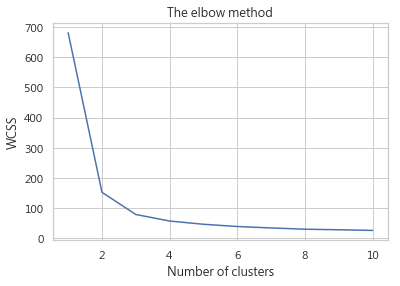

```python
from sklearn.cluster import KMeans
wcss = []

#找出最佳的分群數
for i in range(1, 11):
    kmeans = KMeans(n_clusters = i, init = 'k-means++', max_iter = 300, n_init = 10, random_state = 0)
    kmeans.fit(x)
    wcss.append(kmeans.inertia_)

#- n_clusters:簇的個數，即你想聚成幾類
#- init: 初始簇中心的獲取方法
#- n_init: 獲取初始簇中心的更迭次數，為了彌補初始質心的影響，算法默認會初始10次質心，實現算法，然後返回最好的結果。
#- max_iter: 最大迭代次數（因為kmeans算法的實現需要迭代）
#- random_state: 隨機生成簇中心的狀態條件。



#Plotting the results onto a line graph, allowing us to observe 'The elbow'
plt.plot(range(1, 11), wcss)
plt.title('The elbow method')
plt.xlabel('Number of clusters')
plt.ylabel('WCSS') #within cluster sum of squares
plt.show()
```

```python
#Applying kmeans to the dataset / Creating the kmeans classifier
#已知要分三群
from sklearn import cluster, datasets, metrics

y_pred = cluster.KMeans(n_clusters=3).fit_predict(x) #指定分成3群

# 印出分群結果
print("分群結果：")
print(y_pred)
print("---")

# 印出品種看看
iris_y = iris.target
print("真實品種：")
print(iris_y)
```

```
分群結果：
[1 1 1 1 1 1 1 1 1 1 1 1 1 1 1 1 1 1 1 1 1 1 1 1 1 1 1 1 1 1 1 1 1 1 1 1 1
 1 1 1 1 1 1 1 1 1 1 1 1 1 2 2 0 2 2 2 2 2 2 2 2 2 2 2 2 2 2 2 2 2 2 2 2 2
 2 2 2 0 2 2 2 2 2 2 2 2 2 2 2 2 2 2 2 2 2 2 2 2 2 2 0 2 0 0 0 0 2 0 0 0 0
 0 0 2 2 0 0 0 0 2 0 2 0 2 0 0 2 2 0 0 0 0 0 2 0 0 0 0 2 0 0 0 2 0 0 0 2 0
 0 2]
---
真實品種：
[0 0 0 0 0 0 0 0 0 0 0 0 0 0 0 0 0 0 0 0 0 0 0 0 0 0 0 0 0 0 0 0 0 0 0 0 0
 0 0 0 0 0 0 0 0 0 0 0 0 0 1 1 1 1 1 1 1 1 1 1 1 1 1 1 1 1 1 1 1 1 1 1 1 1
 1 1 1 1 1 1 1 1 1 1 1 1 1 1 1 1 1 1 1 1 1 1 1 1 1 1 2 2 2 2 2 2 2 2 2 2 2
 2 2 2 2 2 2 2 2 2 2 2 2 2 2 2 2 2 2 2 2 2 2 2 2 2 2 2 2 2 2 2 2 2 2 2 2 2
 2 2]
```

### 看起來 setosa 這個品種跟另外兩個品種在花瓣（Petal）的長和寬跟花萼（Sepal）的長和寬有比較大的差異。

```python
# 印出績效
silhouette_avg = metrics.silhouette_score(x, y_pred)
print(silhouette_avg)
```

```
0.5528190123564091
```

## [7-2] Classification (分類)

- 因為一般的分類情況下，我們會希望以圖形呈現
- 但在這一小節，使用Jupyter一律會出現「GraphViz's executables not found」的錯誤訊息
- 因此我們必須解決GraphViz的問題，- 建議的說明如 http://beanobody.blogspot.com/2017/04/graphvizs-executables-not-found.html
- 因課程時數，本小節以 Decision Tree（決策樹）說明，同時不展示圖型

### [注意1] 若需要以圖型展示，另外需要事先

- pip install pydotplus
- conda install graphviz

```python
import seaborn as sns
from sklearn.model_selection import train_test_split
from sklearn.metrics import accuracy_score
from sklearn.externals import joblib

from sklearn import datasets
from sklearn.datasets import load_iris
from sklearn import tree
from sklearn.tree import DecisionTreeClassifier
from sklearn.tree import export_graphviz
from IPython.display import Image
import pydotplus
```

```python
# 讀入鳶尾花資料
iris = load_iris()
iris_X = iris.data
iris_y = iris.target
```

```python
iris.feature_names #看數據庫說明。我們這裡看看 features 有哪些?
```

```
['sepal length (cm)',
 'sepal width (cm)',
 'petal length (cm)',
 'petal width (cm)']
```

```python
train_X, test_X, train_y, test_y = train_test_split(iris_X, iris_y, test_size = 0.3) #測試集30%
```

```python
# 建立分類器
clf = tree.DecisionTreeClassifier()## 生成決策樹
iris_clf = clf.fit(train_X, train_y)
```

```python
# 預測
test_y_predicted = iris_clf.predict(test_X)
print(test_y_predicted)
```

```
[0 1 2 0 1 0 2 0 1 0 1 1 1 1 0 1 2 2 2 1 1 2 1 1 0 0 0 0 1 1 1 1 1 2 2 2 2
 0 1 0 0 0 0 2 2]
```

```python
# 標準答案
print(test_y)
```

```
[0 1 2 0 2 0 2 0 1 0 1 1 1 1 0 1 1 2 2 1 1 2 2 1 0 0 0 0 1 1 2 1 1 2 2 2 2
 0 1 0 0 0 0 2 2]
```

```python
# 績效
from sklearn import metrics

accuracy = metrics.accuracy_score(test_y, test_y_predicted) ## 獲得預測準確率
print(accuracy)
```

```
0.9111111111111111
```

### 資料來源

- https://oranwind.org/python-pandas-ji-chu-jiao-xue/
- https://ithelp.ithome.com.tw/articles/10191774
- https://www.kaggle.com/tonzowonzo/simple-k-means-clustering-on-the-iris-dataset